# Coursework Report

*N* removed NAs: 3

*N* removed typo: 1

*N* removed <18: 22

*N* total clean: 124

| Group | *N* | *M*<sub>age</sub> | *M*<sub>rating</sub> |
| --- | --- | --- | --- |
| Control | 67 | 20.9 | 6.06 |
| Experim | 57 | 20.8 | 5.43 |

**Main analysis results**

*t*(122) = 4.71, *p* < .001

[interactive chart not shown]

[figure not shown]

[interactive chart not shown]

# Coursework Report

Analysing Data, Spring 2020

# Descriptives

Question 1 Descriptive Stats

| mean | sd | min | max |
| --- | --- | --- | --- |
| 5.84 | 1.43 | 3 | 9 |

Question 2 Descriptive Stats

| mean | sd | min | max |
| --- | --- | --- | --- |
| 5.74 | 1.42 | 1 | 9 |

Question 3 Descriptive Stats

| mean | sd | min | max |
| --- | --- | --- | --- |
| 5.72 | 1.38 | 2 | 9 |

# Composite Score

```
## # A tibble: 125 x 3
##    QUESTION_1 QUESTION_2 QUESTION_3
##         <dbl>      <dbl>      <dbl>
##  1          4          6          5
##  2          4          5          5
##  3          5          8          4
##  4          5          6          5
##  5          5          7          4
##  6          7          7          6
##  7          3          6          8
##  8          6          7          4
##  9          6          5          5
## 10          5          6          6
## # ... with 115 more rows
```

# Plots

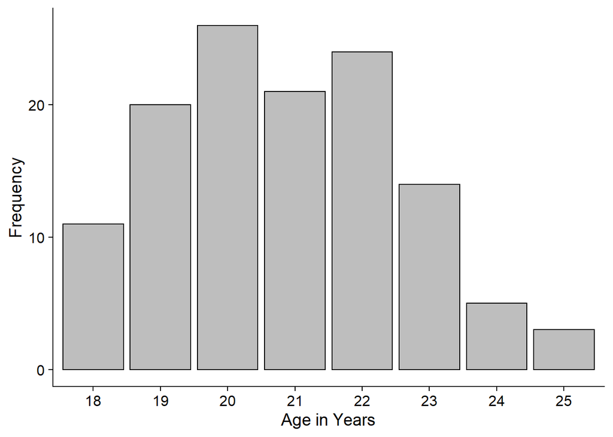

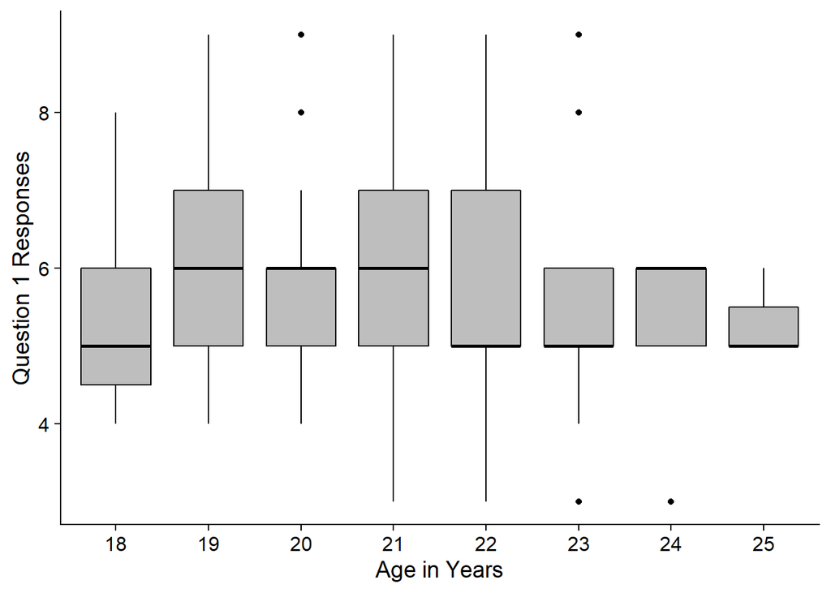

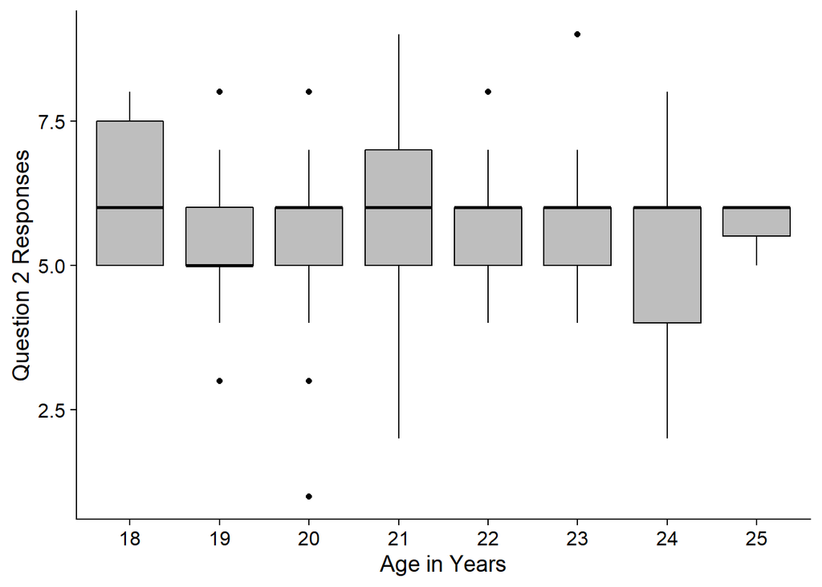

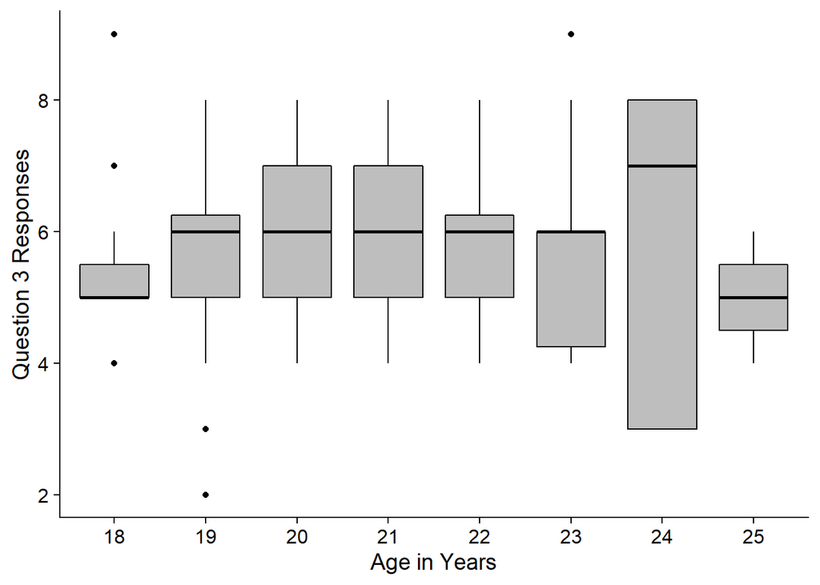

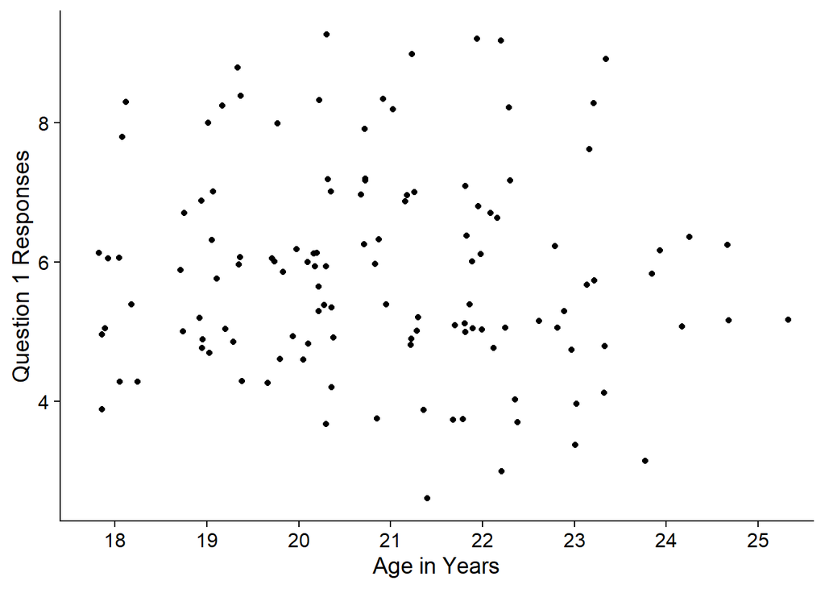

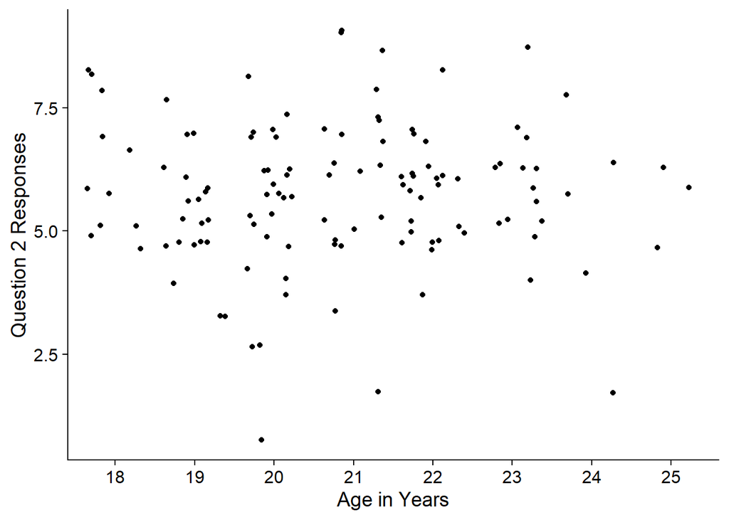

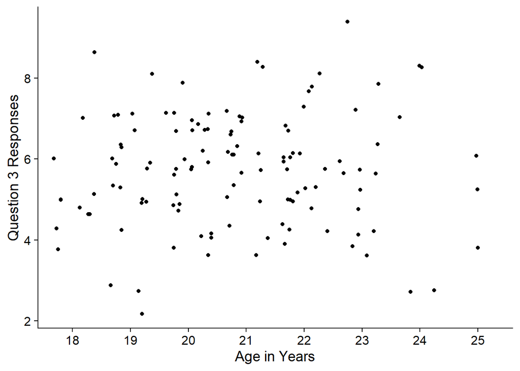

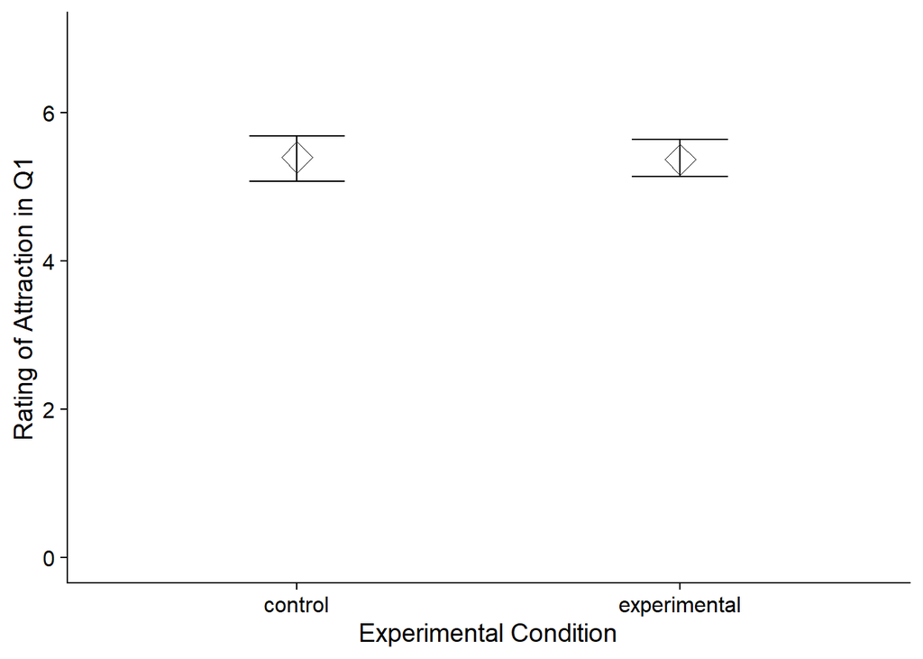

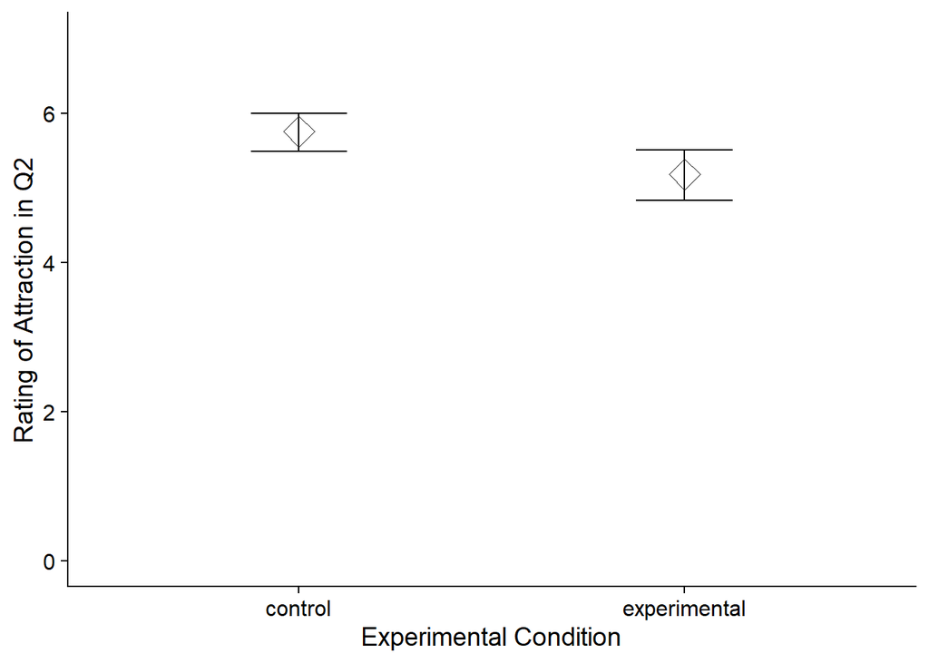

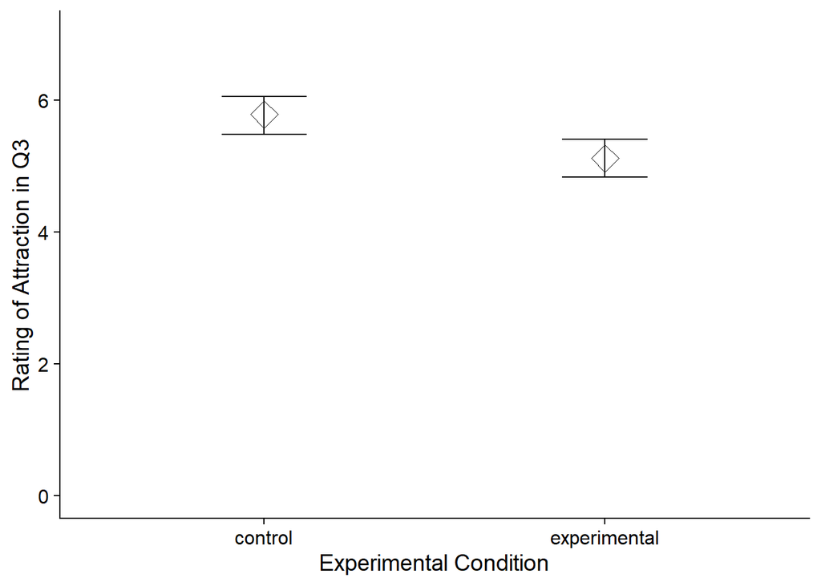

# Analysis - T-Test

```
##
##  Two Sample t-test
##
## data:  QUESTION_1 by CONDITION
## t = 2, df = 122, p-value = 0.1
## alternative hypothesis: true difference in means is not equal to 0
## 95 percent confidence interval:
##  -0.108  0.910
## sample estimates:
##      mean in group control mean in group experimental
##                       6.01                       5.61
```

```
##
##  Two Sample t-test
##
## data:  QUESTION_2 by CONDITION
## t = 4, df = 122, p-value = 0.0005
## alternative hypothesis: true difference in means is not equal to 0
## 95 percent confidence interval:
##  0.387 1.350
## sample estimates:
##      mean in group control mean in group experimental
##                       6.15                       5.28
```

```
##
##  Two Sample t-test
##
## data:  QUESTION_3 by CONDITION
## t = 3, df = 122, p-value = 0.009
## alternative hypothesis: true difference in means is not equal to 0
## 95 percent confidence interval:
##  0.163 1.124
## sample estimates:
##      mean in group control mean in group experimental
##                       6.03                       5.39
```

# Methods

## Design

The research question for this study was whether the colours red and white had an effect on a woman’s perceptions of a man’s attractiveness. The colour white was chosen to contrast the colour red because it is rated to attract the least attention of the neutral colour scheme. Each variable within the study was fully operationalised. The first variable in this study was attractiveness, which was operationalised through three rating scales. These consisted of three items being: “How attractive do you think this person is?”, “How pleasant is this person to look at?” and “If I were to meet this person in this picture face to face, I would think he is attractive.” Each of these items were rated on a 9-point scale, which ranged from 1 (being not at all attractive) and 9 (being extremely attractive). This would be interpreted so that high ratings show high attraction and low ratings shows low attraction in comparison. Another variable was the photo that the female participants viewed. These were on a red background for one condition and on a white background for the second condition, with both photos being in black and white. All of the photos were 4 inches x 6 inches with the same man featured in each one, who was young, Caucasian, had brown hair and was wearing a button up shirt. Therefore, the fully operationalised research question for this study is whether the colours of red and white backgrounds on photos of a male had any effect on women’s attraction towards males, measured through three face-valid items. In order to analyse the results, I will use a “T-test” to test the distribution of the results under the null hypothesis.

# Results

Participant’s opinions of attractiveness were rated on three 9-point scales which were analysed and put into three different tables (a table per rating scale), consisting of the summary of the mean, standard deviation, the maximum and the minimum, which allows us to work out the range. Question 1 of “How attractive do you think this person is?” scored the highest mean of 5.83, whereas question 3 of “If I were to meet this person in this picture face to face, I would think he is attractive.” scored the lowest mean of 5.73. Question 1 also had the smallest range, showing that the ratings from the women were also close together and so more consistent. In terms of standard deviation, question 1 scored the highest and this may mean that the data is less reliable due to the fact that the data is more widely spread than items 2 and 3.

Question 1 Descriptive Stats

| mean | sd | min | max |
| --- | --- | --- | --- |
| 5.84 | 1.43 | 3 | 9 |

Question 2 Descriptive Stats

| mean | sd | min | max |
| --- | --- | --- | --- |
| 5.74 | 1.42 | 1 | 9 |

Question 3 Descriptive Stats

| mean | sd | min | max |
| --- | --- | --- | --- |
| 5.72 | 1.38 | 2 | 9 |

The T-Test results give us the confidence levels, meaning the expression of the researchers confidence in the data obtained from the sample and the mean sample estimates for each question and condition that the participant was assigned to. For question 1 in the control group condition, the mean was 6.01 (2 d.p) and for the experimental condition the mean was 5.61 (2 d.p). This is displaying that the control group rated the photos of the men more attractive on average than the experimental condition. This result is repeated for questions 2 and 3, with the control condition giving higher ratings of attractiveness than the experimental conditions. The t-tests also gave us a “t” value for each item/ question, which is the ratio of the estimated parameter from the hypothesised value in relation to the standard error of results. The highest “t” value score comes with question 2, it being 3.57 (2 d.p). As this is the greatest “t” value out of the three items, this shows that question 2’s results are most significantly different from the average score in this condition. In comparison, the lowest “t” value is from question 1, supporting the conclusions made below in that the results are more consistent with the average.

```
##
##  Two Sample t-test
##
## data:  QUESTION_1 by CONDITION
## t = 2, df = 122, p-value = 0.1
## alternative hypothesis: true difference in means is not equal to 0
## 95 percent confidence interval:
##  -0.108  0.910
## sample estimates:
##      mean in group control mean in group experimental
##                       6.01                       5.61
```

```
##
##  Two Sample t-test
##
## data:  QUESTION_2 by CONDITION
## t = 4, df = 122, p-value = 0.0005
## alternative hypothesis: true difference in means is not equal to 0
## 95 percent confidence interval:
##  0.387 1.350
## sample estimates:
##      mean in group control mean in group experimental
##                       6.15                       5.28
```

```
##
##  Two Sample t-test
##
## data:  QUESTION_3 by CONDITION
## t = 3, df = 122, p-value = 0.009
## alternative hypothesis: true difference in means is not equal to 0
## 95 percent confidence interval:
##  0.163 1.124
## sample estimates:
##      mean in group control mean in group experimental
##                       6.03                       5.39
```

The mean score plots visually display the differences in the mean between the control and experimental conditions for each of the three items. These plots clearly show how the mean scores for each of the three items in the control condition were at least slightly higher than the means in the experimental condition. Question 1 has the closest means, with the control condition still having a higher mean score, but not by a large amount.

[figure not shown]

[figure not shown]

[figure not shown]

# Discussion

From the results analysed above, it is clear that the control condition had the more positive effect on women’s ratings of attractiveness towards men. The mean scores were higher, at least by a small amount, for each of the three 9-point rating scales showing that women in the control condition found the men in the photos they looked at more attractive. This control condition consisted of observing men in black and white photos with a white background, whereas participants in the experimental condition observed men in black and white photos but with a red background. Therefore, this implies that women in the condition with the white background found the photos of the men more attractive.

These findings may be salient in contribution to the research area, as they differ from the results in Elliot’s original study of “Red, rank, and romance in women viewing men”. Results in the original study displayed a “significant colour effect” with participants in the red experimental condition rating the men in the photos more attractive than participants in the white control condition (Elliot, A.J, 2010). The results that we got from replicating this study are vastly different to this, in fact that are completely opposite. This may mean that the colour relation to attractiveness effect that has been investigated is completely down to chance. An explanation for this could be participant effects and individual differences concerning personal taste on whether a woman finds the man in the photo attractive, not due to the colour of the background. Therefore, Elliot’s original study may be said to be unreliable and unreplicable due to results being inconsistent when repeated again.

In comparison to other studies and replication attempts, this replication I carried out relates more to these rather than the original study in 2010. One study found that, through analysis, the “reported statistics and experiments” carried out in Elliot’s original study lack adequate capability to support the claim that women find men more attractive in coalition with the colour red (Francis G, 2013). Francis discusses limitations to Elliot’s experiments and issues with the way that they were run, as well as a “publication bias” being present, which he claims makes the original study “nonscientific” and informal. It is stated that the results in Elliot’s study are not plausible due to how consistent they are across all seven different experiments. Replication studies, such as Hesslinger’s study of “Men in Red”, can be used to assess the reliability of the original study. The same photo that was presented to participants in Elliot’s study was presented to the participants in this repeated study, with an increased sample size, and results implied that there was not any “significant impact of red” that increased any perceived attractiveness in men from women (Hesslinger, 2015). This is therefore similar to my replication results and again completely opposed to Elliot’s original study. However, Hesslinger’s study did find an effect that was significant in attractiveness ratings, which was between men wearing formal attire vs casual attire: men dressed in the formal wear achieving higher attractiveness ratings. These results are questioning the validity of the conclusions from the original study. Hesslinger discusses Elliot’s issues with ecological validity in particular within the experiment due to the neglect of “apparel style” influencing perceived attractiveness and also the photo used meant that stimuli was restricted due to only one man being used in the photos. This obviously does not reflect wider society and the variation of physical appearances found in the world. Both Francis and Hesslinger’s studies are pointing out valid issues with Elliot’s original study, leaving the question of whether it is as valid and reliable as once regarded.

Taking all of these details into consideration, I believe that the effect of increased attraction from women towards men in conjunction with the colour red isn’t real due to the fact that studies replicating Elliot’s original study don’t achieve the same results even slightly. There are also many issues with the way in which this original study was run, making the results even less believable and plausible in relation to the research question.

I don’t believe this research question is worth investigating further as it seems to be concerning women’s individual differences in relation to attraction, rather than attraction in conjunction with red. Next studies should consider further investigating the sole causes of individual differences in women’s attraction, as well as mens, and how things like dress code can affect this perceived attraction, resembling Hesslinger’s study.

In conclusion, it is clear that my replication has not supported Elliot’s original study as I found that the women in the control condition of the white background actually rated their perceived attraction higher than the women in the experimental condition of the red background. This was consistent across all three items and rating scales investigated. Therefore, it is clear that women’s attraction towards men isn’t increased in conjunction with the colour red.

# References

the red-attractiveness effect. Psychon Bull Rev 22, 1142–1148 (2015). https://doi.org/10.3758/s13423-015-0866-8